# Analyses

Non preregistered analyses

Ian Hussey

12 november 2020

Same core research questions as preregistered (i.e., can real and deepfaked content establish evaluative learning), but a single form of multilevel Bayesian model. This has the benefit of summarizing evidence across studies, not mixing Frequentist and semi-Bayesian methods (p values and BF), and making the comparison of genuine vs deepfaked content more intuitive (i.e., via non-inferiority test and percent effectiveness).

# Dependencies & functions

```r
# dependencies
library(tidyverse)
library(knitr)
library(kableExtra)
library(brms)
library(parallel)
library(tidybayes)
library(bayestestR)
library(sjPlot)
library(psych)
library(rsample)
library(broom)
library(purrr)

options(knitr.kable.NA = "/")

# set seed for bootstrapping reproducibility
set.seed(42)

# create necessary folder
dir.create("models")
```

# Data, exclusions, & transformtions

NB all DVs were standardised by 1SD, within each experiment, experiment_condition, and source_valence. Beta estimtes from models are thereofore standardized betas, and the nature of the standardization makes them somewhat comparable to Cohen’s *d*. See Lorah (2018) Effect size measures for multilevel models: definition, interpretation, and TIMSS example. Large-scale Assess Educ 6, 8. https://doi.org/10.1186/s40536-018-0061-2

```r
# full data
data_processed <- read.csv("../data/processed/4_data_participant_level_with_hand_scoring.csv") %>%
  # set factor levels for t test comparisons
  mutate(source_valence = fct_relevel(source_valence,
                                      "negative",
                                      "positive"),
         experiment_condition = fct_relevel(experiment_condition,
                                            "genuine",
                                            "deepfaked"),
         experiment = as.factor(experiment))

# apply exclusions
data_after_exclusions <- data_processed %>%
  filter(exclude_subject == FALSE) %>%
  # standardize by experiment and conditions
  group_by(experiment, experiment_condition, source_valence) %>%
  mutate(mean_self_reported_evaluation = mean_self_reported_evaluation/sd(mean_self_reported_evaluation),
         IAT_D2 = IAT_D2/sd(IAT_D2),
         mean_intentions = mean_intentions/sd(mean_intentions)) %>%
  ungroup()
```

# Distributions

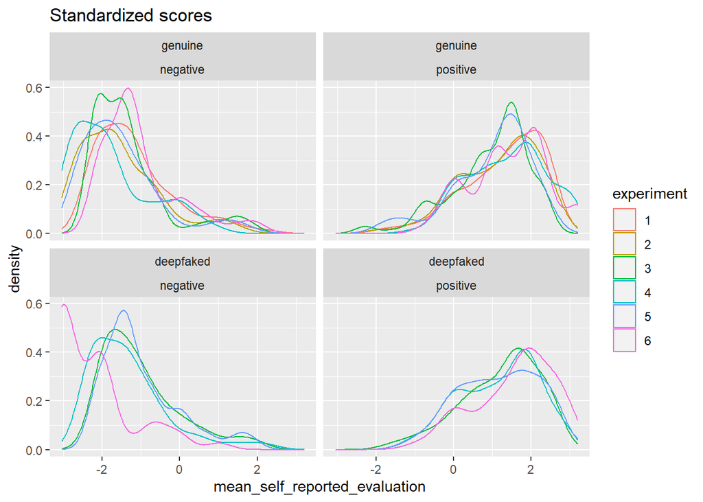

```r
ggplot(data_after_exclusions, aes(mean_self_reported_evaluation, color = experiment)) +
  geom_density() +
  facet_wrap( ~ experiment_condition + source_valence) +
  ggtitle("Standardized scores")
```

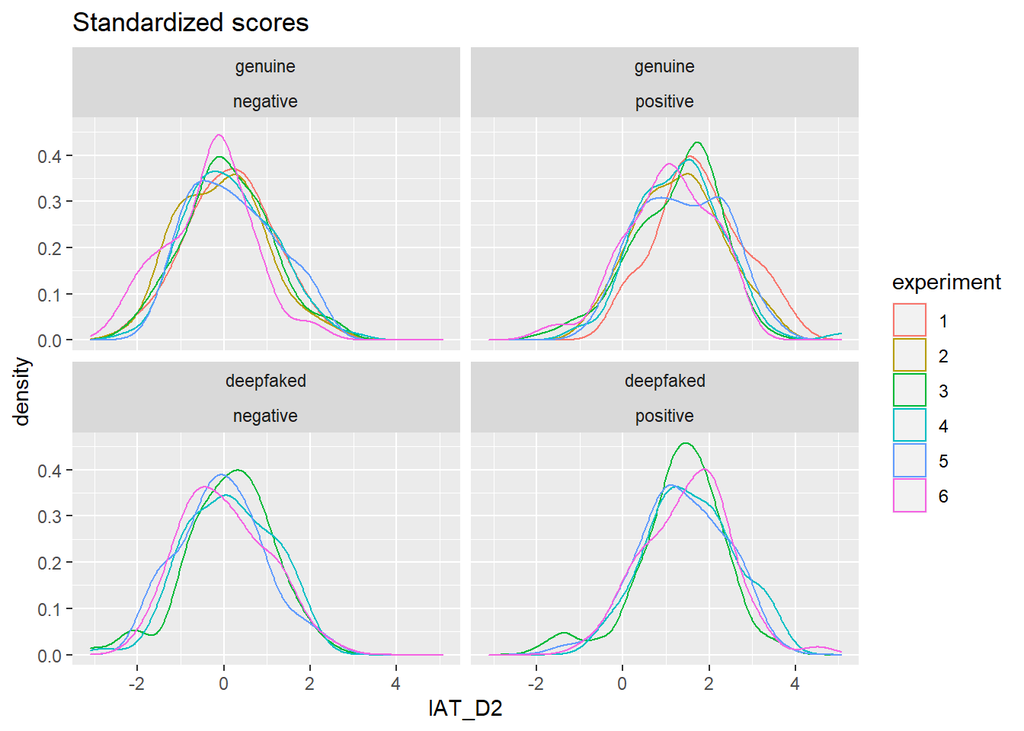

```r
ggplot(data_after_exclusions, aes(IAT_D2, color = experiment)) +
  geom_density() +
  facet_wrap( ~ experiment_condition + source_valence) +
  ggtitle("Standardized scores")
```

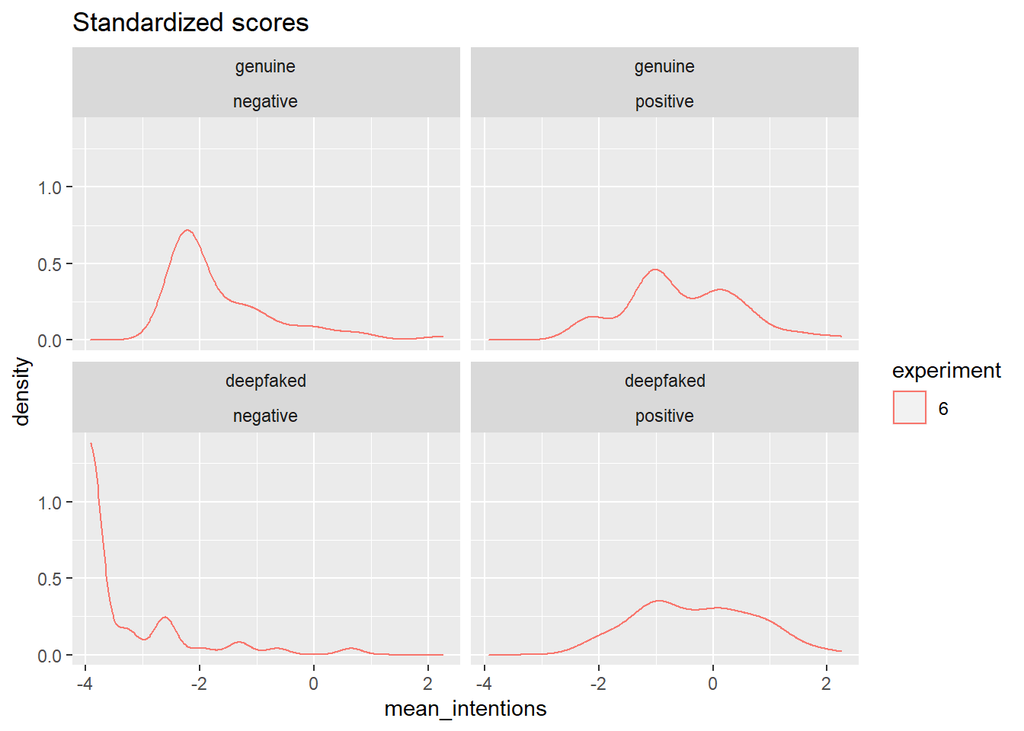

```r
ggplot(data_after_exclusions, aes(mean_intentions, color = experiment)) +
  geom_density() +
  facet_wrap( ~ experiment_condition + source_valence) +
  ggtitle("Standardized scores")
```

# Demographics

```r
data_processed %>%
  group_by(experiment) %>%
  summarise(n = n(),
            excluded_n = sum(exclude_subject > 0),
            excluded_percent = (excluded_n / n) *100) %>%
  mutate_if(is.numeric, round, digits = 1) %>%
  kable(align = "c") %>%
  kable_styling()
```

| experiment | n | excluded_n | excluded_percent |
| --- | --- | --- | --- |
| 1 | 165 | 17 | 10.3 |
| 2 | 167 | 32 | 19.2 |
| 3 | 428 | 70 | 16.4 |
| 4 | 429 | 88 | 20.5 |
| 5 | 276 | 55 | 19.9 |
| 6 | 265 | 47 | 17.7 |

```r
data_after_exclusions %>%
  group_by(experiment) %>%
  summarise(n = n(),
            age_mean = mean(age, na.rm = TRUE),
            age_sd = sd(age, na.rm = TRUE)) %>%
  mutate_if(is.numeric, round, digits = 1) %>%
  kable(align = "c") %>%
  kable_styling()
```

| experiment | n | age_mean | age_sd |
| --- | --- | --- | --- |
| 1 | 148 | 30.0 | 7.7 |
| 2 | 135 | 31.0 | 7.4 |
| 3 | 358 | 30.0 | 8.8 |
| 4 | 341 | 30.2 | 9.0 |
| 5 | 221 | 31.2 | 11.4 |
| 6 | 218 | 33.4 | 12.7 |

```r
data_after_exclusions %>%
  count(experiment, gender) %>%
  spread(gender, n) %>%
  kable(knitr.kable.NA = "/", align = "c") %>%
  kable_styling(bootstrap_options = c("striped", "hover", "condensed"),
                full_width = FALSE)
```

| experiment | female | male | Non-binary | other | Prefer not to disclose |
| --- | --- | --- | --- | --- | --- |
| 1 | 68 | 79 | / | 1 | / |
| 2 | 78 | 57 | / | / | / |
| 3 | 196 | 158 | / | 4 | / |
| 4 | 199 | 140 | / | 2 | / |
| 5 | 123 | 95 | 2 | / | 1 |
| 6 | 129 | 87 | 2 | / | / |

# Changing evaluations

- Analyses employ Bayesian multilevel models with experiment employed as a random (Group level) intercept, and source_valence, experiment_condition and their interaction as IVs. This could therefore be described as akin to a Bayesian multilevel ANOVA.
- DVs were standardize as noted above, and as such fitted model estimates represent standardized beta values (which due to the specifics of the standardization have comparable [but not exact] interpretation as Cohen’s d values).
- Bayesian p values are also reported: these are on a similar scale to frequentist p values, but technically are 1 minus the posterior probability that the effect is greater than 0, i.e., $1 - P(\beta>0)$.
- Inspection of the posterior distributions allow us to infer that we employed weak priors placed on all parameters (normal distribution with M = 0 and SD = 10). Inspection of the chains indicated good convergence in all cases.

## Sample sizes

```r
data_after_exclusions %>%
  select(source_valence,
         experiment_condition) %>%
  drop_na() %>%
  count(experiment_condition,
        source_valence) %>%
  kable() %>%
  kable_styling(bootstrap_options = c("striped", "hover", "condensed"),
                full_width = FALSE)
```

| experiment_condition | source_valence | n |
| --- | --- | --- |
| genuine | negative | 401 |
| genuine | positive | 449 |
| deepfaked | negative | 271 |
| deepfaked | positive | 300 |

## Self-reported evaluations

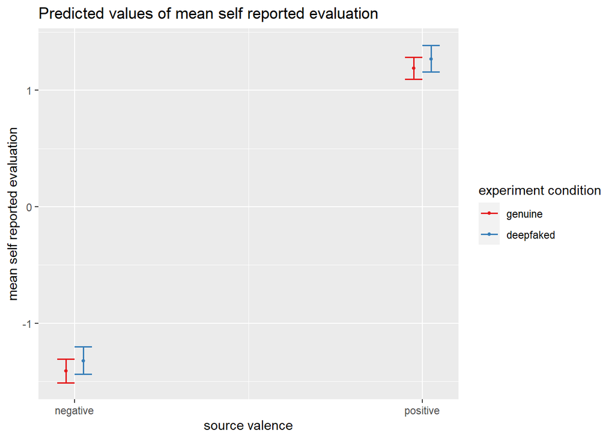

```r
fit_selfreport <-
  brm(formula = mean_self_reported_evaluation ~ source_valence * experiment_condition + (1 | experiment),
      data    = data_after_exclusions,
      file    = "models/fit_selfreport",
      prior   = prior(normal(0, 10)),
      iter    = 6000,
      warmup  = 3000,
      control = list(adapt_delta = 0.99),  # to avoid divergent transitions
      chains  = 4,
      cores   = parallel::detectCores())

# # inspect convergence
# fit_selfreport
# plot(fit_selfreport, ask = FALSE)

# plot_model(fit_selfreport)
# plot_model(fit_selfreport, type = "re")
plot_model(fit_selfreport, type = "pred", terms = c("source_valence", "experiment_condition"))
```

```r
# percent moderation
draws_sr <-
  bind_cols(
    select(spread_draws(fit_selfreport, b_source_valencepositive), b_source_valencepositive),
    select(spread_draws(fit_selfreport, b_experiment_conditiondeepfaked), b_experiment_conditiondeepfaked),
    select(spread_draws(fit_selfreport, `b_source_valencepositive:experiment_conditiondeepfaked`), `b_source_valencepositive:experiment_conditiondeepfaked`)
  ) %>%
  rename(main_valence = b_source_valencepositive,
         main_experiment_condition = b_experiment_conditiondeepfaked,
         interaction = `b_source_valencepositive:experiment_conditiondeepfaked`) %>%
  mutate(effect_genuine = main_valence,
         effect_deepfaked = main_valence + main_experiment_condition + interaction,
         #percent_moderation = (main_experiment_condition + interaction)/main_valence *100,  # alt method, same result
         percent_comparison = (effect_deepfaked/effect_genuine)*100)

# results
estimates_sr <-
  map_estimate(draws_sr) %>%
  full_join(bayestestR::hdi(draws_sr, ci = .95) %>%
              rename(CI_95_lower = CI_low,
                     CI_95_upper = CI_high) %>%
              as_tibble(),
            by = "Parameter") %>%
  full_join(bayestestR::hdi(draws_sr, ci = .90) %>%
              as_tibble() %>%
              rename(CI_90_lower = CI_low,
                     CI_90_upper = CI_high),
            by = "Parameter") %>%
  full_join(draws_sr %>%
              select(-percent_comparison) %>%
              gather(Parameter, value) %>%
              group_by(Parameter) %>%
              summarize(pd = mean(value > 0)) %>%
              mutate(p = pd_to_p(pd, direction = "one-sided")) %>%
              ungroup() %>%
              select(Parameter, p),
            by = "Parameter") %>%
  select(Parameter, MAP_Estimate, CI_95_lower, CI_95_upper,
         CI_90_lower, CI_90_upper, p)

comparison_string_sr <-
  paste0("Deepfakes are ",
         estimates_sr %>%
           filter(Parameter == "percent_comparison") %>%
           pull(MAP_Estimate) %>%
           round(1),
         "% (95% CI [",
         estimates_sr %>%
           filter(Parameter == "percent_comparison") %>%
           pull(CI_95_lower) %>%
           round(1),
         ", ",
         estimates_sr %>%
           filter(Parameter == "percent_comparison") %>%
           pull(CI_95_upper) %>%
           round(1),
         "]) as effective as genine content in changing self-reported evaluations")

noninferiority_sr <-
  paste0(ifelse(estimates_sr %>%
                  filter(Parameter == "effect_genuine") %>%
                  pull(CI_95_lower) <
                  estimates_sr %>%
                  filter(Parameter == "effect_deepfaked") %>%
                  pull(CI_90_lower),
                "Deepfakes were found to be non-inferior to genuine content: ",
                "Deepfakes were not found to be non-inferior to genuine content: "),
         "genuine condition lowerbound 95% CI = ",
         estimates_sr %>%
           filter(Parameter == "effect_genuine") %>%
           pull(CI_95_lower) %>%
           round(2),
         ", deepfaked condition lowerbound 90% CI = ",
         estimates_sr %>%
           filter(Parameter == "effect_deepfaked") %>%
           pull(CI_90_lower) %>%
           round(2))

estimates_sr %>%
  mutate_at(.vars = c("MAP_Estimate", "CI_95_lower", "CI_95_upper", "CI_90_lower", "CI_90_upper"), round, digits = 2) %>%
  kable() %>%
  kable_styling(bootstrap_options = c("striped", "hover", "condensed"),
                full_width = FALSE)
```

| Parameter | MAP_Estimate | CI_95_lower | CI_95_upper | CI_90_lower | CI_90_upper | p |
| --- | --- | --- | --- | --- | --- | --- |
| main_valence | 2.61 | 2.45 | 2.73 | 2.48 | 2.72 | 0.0000000 |
| main_experiment_condition | 0.09 | -0.08 | 0.25 | -0.05 | 0.22 | 0.1405833 |
| interaction | -0.01 | -0.23 | 0.21 | -0.19 | 0.17 | 0.5269167 |
| effect_genuine | 2.61 | 2.45 | 2.73 | 2.48 | 2.72 | 0.0000000 |
| effect_deepfaked | 2.68 | 2.52 | 2.83 | 2.55 | 2.81 | 0.0000000 |
| percent_comparison | 102.70 | 96.95 | 108.75 | 98.08 | 108.02 | / |

Deepfakes were found to be non-inferior to genuine content: genuine condition lowerbound 95% CI = 2.45, deepfaked condition lowerbound 90% CI = 2.55

Deepfakes are 102.7% (95% CI [96.9, 108.8]) as effective as genine content in changing self-reported evaluations

## Implicit

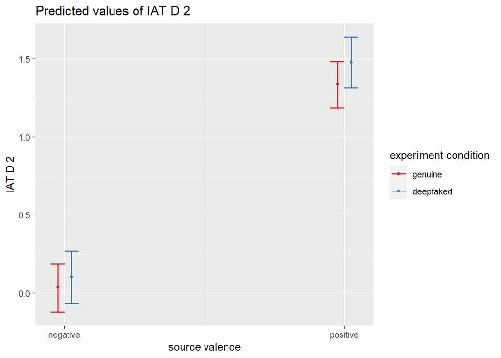

```r
fit_implicit <-
  brm(formula = IAT_D2 ~ source_valence * experiment_condition + (1 | experiment),
      data    = data_after_exclusions,
      file    = "models/fit_implicit",
      prior   = prior(normal(0, 10)),
      iter    = 6000,
      warmup  = 3000,
      control = list(adapt_delta = 0.99),  # to avoid divergent transitions
      chains  = 4,
      cores   = parallel::detectCores())

# # inspect convergence
# fit_implicit
# plot(fit_implicit, ask = FALSE)

#plot_model(fit_implicit)
plot_model(fit_implicit, type = "pred", terms = c("source_valence", "experiment_condition"))
```

```r
# percent moderation
draws_imp <-
  bind_cols(
    select(spread_draws(fit_implicit, b_source_valencepositive), b_source_valencepositive),
    select(spread_draws(fit_implicit, b_experiment_conditiondeepfaked), b_experiment_conditiondeepfaked),
    select(spread_draws(fit_implicit, `b_source_valencepositive:experiment_conditiondeepfaked`), `b_source_valencepositive:experiment_conditiondeepfaked`)
  ) %>%
  rename(main_valence = b_source_valencepositive,
         main_experiment_condition = b_experiment_conditiondeepfaked,
         interaction = `b_source_valencepositive:experiment_conditiondeepfaked`) %>%
  mutate(effect_genuine = main_valence,
         effect_deepfaked = main_valence + main_experiment_condition + interaction,
         #percent_moderation = (main_experiment_condition + interaction)/main_valence *100,  # alt method, same result
         percent_comparison = (effect_deepfaked/effect_genuine)*100)

# results
estimates_imp <-
  map_estimate(draws_imp) %>%
  full_join(bayestestR::hdi(draws_imp, ci = .95) %>%
              rename(CI_95_lower = CI_low,
                     CI_95_upper = CI_high) %>%
              as_tibble(),
            by = "Parameter") %>%
  full_join(bayestestR::hdi(draws_imp, ci = .90) %>%
              as_tibble() %>%
              rename(CI_90_lower = CI_low,
                     CI_90_upper = CI_high),
            by = "Parameter") %>%
  full_join(draws_imp %>%
              select(-percent_comparison) %>%
              gather(Parameter, value) %>%
              group_by(Parameter) %>%
              summarize(pd = mean(value > 0)) %>%
              mutate(p = pd_to_p(pd, direction = "one-sided")) %>%
              ungroup() %>%
              select(Parameter, p),
            by = "Parameter") %>%
  select(Parameter, MAP_Estimate, CI_95_lower, CI_95_upper,
         CI_90_lower, CI_90_upper, p)

comparison_string_imp <-
  paste0("Deepfakes are ",
         estimates_imp %>%
           filter(Parameter == "percent_comparison") %>%
           pull(MAP_Estimate) %>%
           round(1),
         "% (95% CI [",
         estimates_imp %>%
           filter(Parameter == "percent_comparison") %>%
           pull(CI_95_lower) %>%
           round(1),
         ", ",
         estimates_imp %>%
           filter(Parameter == "percent_comparison") %>%
           pull(CI_95_upper) %>%
           round(1),
         "]) as effective as genine content in changing implicit attitudes")

noninferiority_imp <-
  paste0(ifelse(estimates_imp %>%
                  filter(Parameter == "effect_genuine") %>%
                  pull(CI_95_lower) <
                  estimates_imp %>%
                  filter(Parameter == "effect_deepfaked") %>%
                  pull(CI_90_lower),
                "Deepfakes were found to be non-inferior to genuine content: ",
                "Deepfakes were not found to be non-inferior to genuine content: "),
         "genuine condition lowerbound 95% CI = ",
         estimates_imp %>%
           filter(Parameter == "effect_genuine") %>%
           pull(CI_95_lower) %>%
           round(2),
         ", deepfaked condition lowerbound 90% CI = ",
         estimates_imp %>%
           filter(Parameter == "effect_deepfaked") %>%
           pull(CI_90_lower) %>%
           round(2))

estimates_imp %>%
  mutate_at(.vars = c("MAP_Estimate", "CI_95_lower", "CI_95_upper", "CI_90_lower", "CI_90_upper"), round, digits = 2) %>%
  kable() %>%
  kable_styling(bootstrap_options = c("striped", "hover", "condensed"),
                full_width = FALSE)
```

| Parameter | MAP_Estimate | CI_95_lower | CI_95_upper | CI_90_lower | CI_90_upper | p |
| --- | --- | --- | --- | --- | --- | --- |
| main_valence | 1.31 | 1.17 | 1.44 | 1.19 | 1.42 | 0.0000000 |
| main_experiment_condition | 0.06 | -0.10 | 0.23 | -0.07 | 0.20 | 0.2065833 |
| interaction | 0.07 | -0.14 | 0.29 | -0.11 | 0.25 | 0.2633333 |
| effect_genuine | 1.31 | 1.17 | 1.44 | 1.19 | 1.42 | 0.0000000 |
| effect_deepfaked | 1.45 | 1.28 | 1.60 | 1.31 | 1.57 | 0.0000000 |
| percent_comparison | 110.32 | 98.30 | 123.06 | 100.60 | 121.21 | / |

Deepfakes were found to be non-inferior to genuine content: genuine condition lowerbound 95% CI = 1.17, deepfaked condition lowerbound 90% CI = 1.31

Deepfakes are 110.3% (95% CI [98.3, 123.1]) as effective as genine content in changing implicit attitudes

## Behavioural intentions

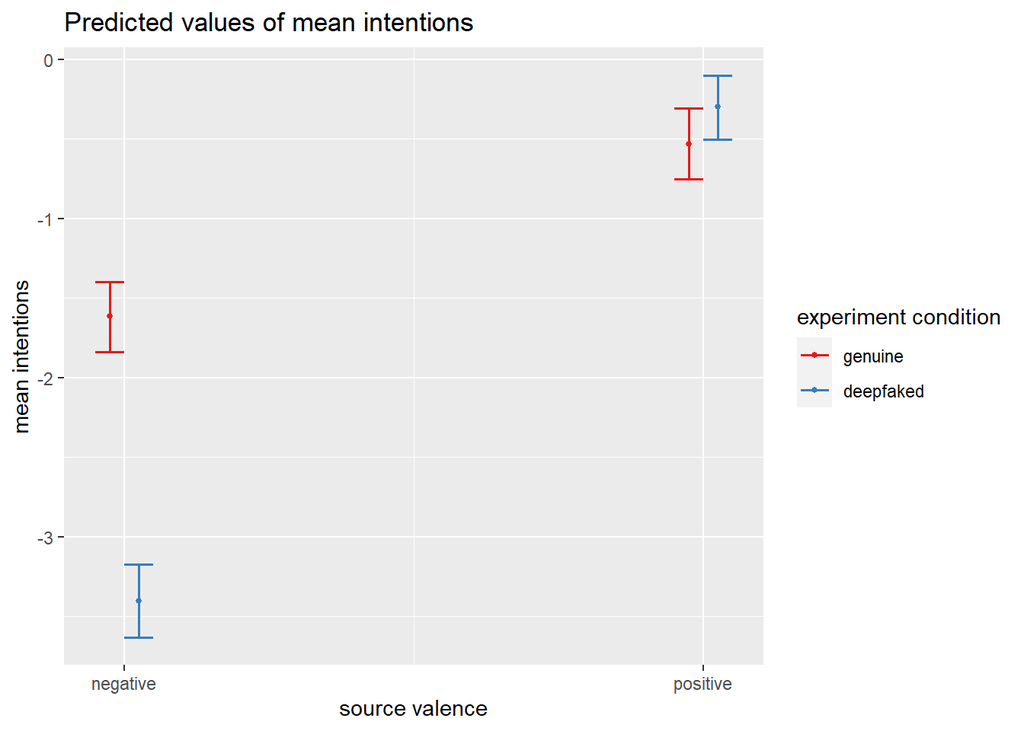

```r
fit_intentions <-
  brm(formula = mean_intentions ~ source_valence * experiment_condition, # no random effect for experiment as only exp 6 assessed intentions
      data    = data_after_exclusions,
      file    = "models/fit_intentions",
      prior   = prior(normal(0, 10)),
      iter    = 6000,
      warmup  = 3000,
      control = list(adapt_delta = 0.99),  # to avoid divergent transitions
      chains  = 4,
      cores   = parallel::detectCores())

# # inspect convergence
# fit_intentions
# plot(fit_intentions, ask = FALSE)

#plot_model(fit_intentions)
plot_model(fit_intentions, type = "pred", terms = c("source_valence", "experiment_condition"))
```

```r
# percent moderation
draws_intentions <-
  bind_cols(
    select(spread_draws(fit_intentions, b_source_valencepositive), b_source_valencepositive),
    select(spread_draws(fit_intentions, b_experiment_conditiondeepfaked), b_experiment_conditiondeepfaked),
    select(spread_draws(fit_intentions, `b_source_valencepositive:experiment_conditiondeepfaked`), `b_source_valencepositive:experiment_conditiondeepfaked`)
  ) %>%
  rename(main_valence = b_source_valencepositive,
         main_experiment_condition = b_experiment_conditiondeepfaked,
         interaction = `b_source_valencepositive:experiment_conditiondeepfaked`) %>%
  mutate(effect_genuine = main_valence,
         effect_deepfaked = main_valence + main_experiment_condition + interaction,
         #percent_moderation = (main_experiment_condition + interaction)/main_valence *100,  # alt method, same result
         percent_comparison = (effect_deepfaked/effect_genuine)*100)

# results
estimates_intentions <-
  map_estimate(draws_intentions) %>%
  full_join(bayestestR::hdi(draws_intentions, ci = .95) %>%
              rename(CI_95_lower = CI_low,
                     CI_95_upper = CI_high) %>%
              as_tibble(),
            by = "Parameter") %>%
  full_join(bayestestR::hdi(draws_intentions, ci = .90) %>%
              as_tibble() %>%
              rename(CI_90_lower = CI_low,
                     CI_90_upper = CI_high),
            by = "Parameter") %>%
  full_join(draws_intentions %>%
              select(-percent_comparison) %>%
              gather(Parameter, value) %>%
              group_by(Parameter) %>%
              summarize(pd = mean(value > 0)) %>%
              mutate(p = pd_to_p(pd, direction = "one-sided")) %>%
              ungroup() %>%
              select(Parameter, p),
            by = "Parameter") %>%
  select(Parameter, MAP_Estimate, CI_95_lower, CI_95_upper,
         CI_90_lower, CI_90_upper, p)

comparison_string_intentions <-
  paste0("Deepfakes are ",
         estimates_intentions %>%
           filter(Parameter == "percent_comparison") %>%
           pull(MAP_Estimate) %>%
           round(1),
         "% (95% CI [",
         estimates_intentions %>%
           filter(Parameter == "percent_comparison") %>%
           pull(CI_95_lower) %>%
           round(1),
         ", ",
         estimates_intentions %>%
           filter(Parameter == "percent_comparison") %>%
           pull(CI_95_upper) %>%
           round(1),
         "]) as effective as genine content in changing behavioural intentions")

noninferiority_intentions <-
  paste0(ifelse(estimates_intentions %>%
                  filter(Parameter == "effect_genuine") %>%
                  pull(CI_95_lower) <
                  estimates_intentions %>%
                  filter(Parameter == "effect_deepfaked") %>%
                  pull(CI_90_lower),
                "Deepfakes were found to be non-inferior to genuine content: ",
                "Deepfakes were not found to be non-inferior to genuine content: "),
         "genuine condition lowerbound 95% CI = ",
         estimates_intentions %>%
           filter(Parameter == "effect_genuine") %>%
           pull(CI_95_lower) %>%
           round(2),
         ", deepfaked condition lowerbound 90% CI = ",
         estimates_intentions %>%
           filter(Parameter == "effect_deepfaked") %>%
           pull(CI_90_lower) %>%
           round(2))

estimates_intentions %>%
  mutate_at(.vars = c("MAP_Estimate", "CI_95_lower", "CI_95_upper", "CI_90_lower", "CI_90_upper"), round, digits = 2) %>%
  kable() %>%
  kable_styling(bootstrap_options = c("striped", "hover", "condensed"),
                full_width = FALSE)
```

| Parameter | MAP_Estimate | CI_95_lower | CI_95_upper | CI_90_lower | CI_90_upper | p |
| --- | --- | --- | --- | --- | --- | --- |
| main_valence | 1.09 | 0.71 | 1.48 | 0.75 | 1.39 | 0 |
| main_experiment_condition | -1.80 | -2.18 | -1.41 | -2.12 | -1.46 | 1 |
| interaction | 2.04 | 1.47 | 2.52 | 1.58 | 2.47 | 0 |
| effect_genuine | 1.09 | 0.71 | 1.48 | 0.75 | 1.39 | 0 |
| effect_deepfaked | 1.33 | 0.95 | 1.69 | 1.00 | 1.62 | 0 |
| percent_comparison | 117.31 | 84.54 | 166.14 | 89.33 | 156.74 | / |

Deepfakes were found to be non-inferior to genuine content: genuine condition lowerbound 95% CI = 0.71, deepfaked condition lowerbound 90% CI = 1

Deepfakes are 117.3% (95% CI [84.5, 166.1]) as effective as genine content in changing behavioural intentions

# Detection

## Inter-rater relibility

```r
data_after_exclusions %>%
  count(deepfake_detected,
        deepfake_detected_rater_1,
        deepfake_detected_rater_2) %>%
  kable() %>%
  kable_styling(bootstrap_options = c("striped", "hover", "condensed"),
                full_width = FALSE)
```

| deepfake_detected | deepfake_detected_rater_1 | deepfake_detected_rater_2 | n |
| --- | --- | --- | --- |
| FALSE | FALSE | FALSE | 445 |
| FALSE | FALSE | TRUE | 17 |
| FALSE | TRUE | FALSE | 31 |
| TRUE | TRUE | TRUE | 117 |
| / | / | / | 811 |

```r
data_after_exclusions %>%
  summarize(percent_agreement = round(mean(deepfake_detected_rater_1 == deepfake_detected_rater_2, na.rm = TRUE)*100, 1)) %>%
  kable() %>%
  kable_styling(bootstrap_options = c("striped", "hover", "condensed"),
                full_width = FALSE)
```

| percent_agreement |
| --- |
| 92.1 |

```r
data_after_exclusions %>%
  select(deepfake_detected_rater_1,
         deepfake_detected_rater_2) %>%
  as.data.frame() %>%  # kappa function won't take tibbles
  psych::cohen.kappa(.)
```

```
## Call: cohen.kappa1(x = x, w = w, n.obs = n.obs, alpha = alpha, levels = levels)
##
## Cohen Kappa and Weighted Kappa correlation coefficients and confidence boundaries
##                  lower estimate upper
## unweighted kappa  0.72     0.78  0.84
## weighted kappa    0.72     0.78  0.84
##
##  Number of subjects = 610
```

Interpreation of Kappa (Altman 1999, Landis JR, 1977):

- 0.61 - 0.80 Substantial
- 0.81 - 1.00 Almost perfect

## Sample sizes

```r
data_after_exclusions %>%
  count(experiment_condition,
        deepfake_detected) %>%
  drop_na() %>%
  kable() %>%
  kable_styling(bootstrap_options = c("striped", "hover", "condensed"),
                full_width = FALSE)
```

| experiment_condition | deepfake_detected | n |
| --- | --- | --- |
| genuine | FALSE | 200 |
| genuine | TRUE | 17 |
| deepfaked | FALSE | 293 |
| deepfaked | TRUE | 100 |

## Can people accurately detect deepfakes?

- Youden’s J = sensitivity + specificity - 1, aka informedness, aka “the probability of an informed decision (as opposed to a random guess) and takes into account all predictions”
- 95% CIs were bootstrapped via case removal and the percentile method.

```r
if(file.exists("models/fit_classification_bootstraps.rds")){

  fit_classification_bootstraps <- read_rds("models/fit_classification_bootstraps.rds")

} else {

  # create bootstraps using out of bag method. makes a df with values that are collapsed dfs.
  boots <- data_after_exclusions %>%
    select(experiment_condition, deepfake_detected) %>%
    drop_na() %>%
    bootstraps(times = 2000)

  # generalize to a summarize function ------
  bootstrap_categorization_stats <- function(split) {

    data_counts <- analysis(split) %>%
      count(experiment_condition, deepfake_detected)

    TP <- pull(filter(data_counts, experiment_condition == "deepfaked" & deepfake_detected == TRUE),  n)
    FP <- pull(filter(data_counts, experiment_condition == "genuine"   & deepfake_detected == TRUE),  n)
    FN <- pull(filter(data_counts, experiment_condition == "deepfaked" & deepfake_detected == FALSE), n)
    TN <- pull(filter(data_counts, experiment_condition == "genuine"   & deepfake_detected == FALSE), n)

    #accuracy <- (TP+TN)/(TP+TN+FP+FN)
    sensitivity <- TP / (TP+FN)
    false_negative_rate <- 1 - sensitivity
    specificity <- TN / (TN+FP)
    false_positive_rate <- 1 - specificity

    # Youden's J statistic aka informedness aka "the probability of an informed decision (as opposed to a random guess) and takes into account all predictions". a zero value when a diagnostic test gives the same proportion of positive results for groups with and without the disease, i.e the test is useless.
    informedness <- sensitivity + specificity - 1

    balanced_accuracy <- (sensitivity + specificity)/2

    results <-
      tibble(variable = c(
        #"accuracy",
        "balanced_accuracy",
        "informedness",
        #"sensitivity",
        "false_negative_rate",
        #"specificity",
        "false_positive_rate"
      ),
      value = c(
        #accuracy,
        balanced_accuracy,
        informedness,
        #sensitivity,
        false_negative_rate,
        #specificity,
        false_positive_rate
      ))

    return(results)
  }

  # apply to each bootstrap
  fit_classification_bootstraps <- boots %>%
    mutate(categorization_stats = map(splits, bootstrap_categorization_stats)) %>%
    select(-splits) %>%
    unnest(categorization_stats)

  write_rds(fit_classification_bootstraps, "models/fit_classification_bootstraps.rds")

}

fit_classification_bootstraps %>%
  group_by(variable) %>%
  summarize(median = quantile(value, 0.500),
            ci_lower = quantile(value, 0.025),
            ci_upper = quantile(value, 0.975),
            .groups = "drop") %>%
  mutate_if(is.numeric, round, digits = 2) %>%
  kable() %>%
  kable_styling(bootstrap_options = c("striped", "hover", "condensed"),
                full_width = FALSE)
```

| variable | median | ci_lower | ci_upper |
| --- | --- | --- | --- |
| balanced_accuracy | 0.59 | 0.56 | 0.62 |
| false_negative_rate | 0.75 | 0.70 | 0.79 |
| false_positive_rate | 0.08 | 0.04 | 0.12 |
| informedness | 0.18 | 0.12 | 0.23 |

# Does detecting it matter?

Subset who received deepfaked videos but also detected them. Same Bayesian multilevel models as employed above, using only source_valence as IV, i.e., to detect whether learning effects are credibly non-zero in this subset.

## Sample sizes

```r
data_detectors_subset <- data_after_exclusions %>%
  filter(experiment_condition == "deepfaked" & deepfake_detected == TRUE)

data_detectors_subset %>%
  count(source_valence) %>%
  rename(n_experiments_4_to_6 = n) %>%
  kable() %>%
  kable_styling(bootstrap_options = c("striped", "hover", "condensed"),
                full_width = FALSE)
```

| source_valence | n_experiments_4_to_6 |
| --- | --- |
| negative | 51 |
| positive | 49 |

```r
data_detectors_subset %>%
  filter(experiment == 6) %>%
  count(source_valence) %>%
  rename(n_experiment_6 = n) %>%
  kable() %>%
  kable_styling(bootstrap_options = c("striped", "hover", "condensed"),
                full_width = FALSE)
```

| source_valence | n_experiment_6 |
| --- | --- |
| negative | 14 |
| positive | 10 |

Intentions DV present only in exp 6. N is particularly low for this analysis, so results should be taken with additional caution.

## Self-reported evaluations

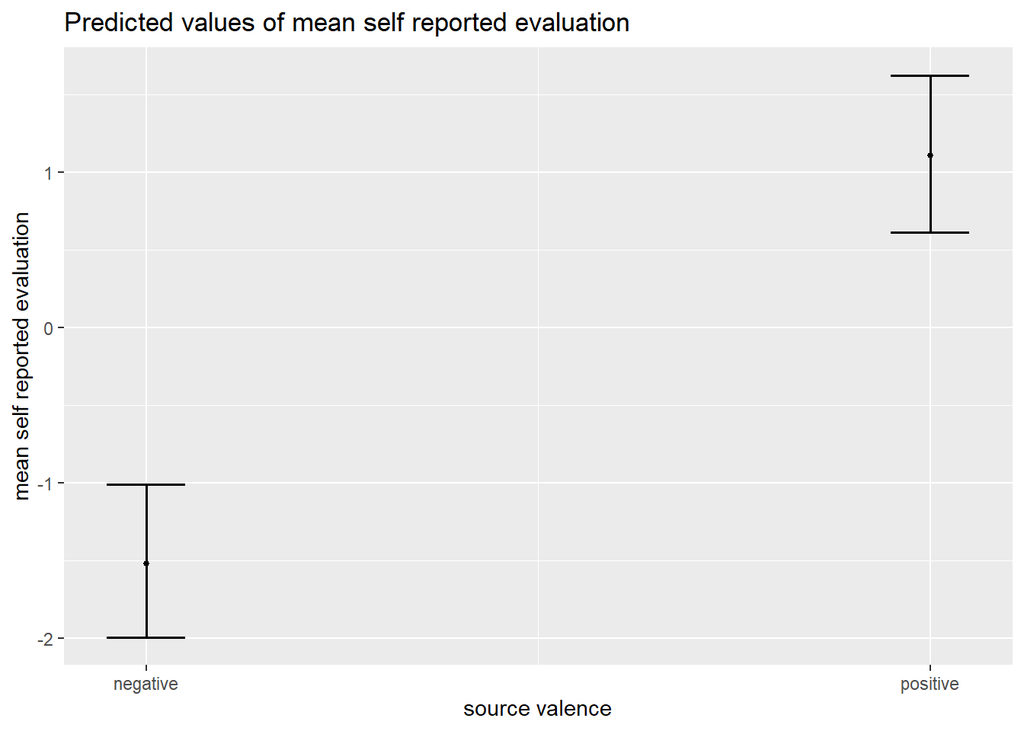

```r
fit_selfreport_deepfaked_detected <-
  brm(formula = mean_self_reported_evaluation ~ source_valence + (1 | experiment),
      data    = data_detectors_subset,
      file    = "models/fit_selfreport_deepfaked_detected",
      prior   = prior(normal(0, 10)),
      iter    = 6000,
      warmup  = 3000,
      control = list(adapt_delta = 0.99),  # to avoid divergent transitions
      chains  = 4,
      cores   = parallel::detectCores())

# # inspect convergence
# fit_selfreport_deepfaked_detected
# plot(fit_selfreport_deepfaked_detected, ask = FALSE)

#plot_model(fit_selfreport_deepfaked_detected)
plot_model(fit_selfreport_deepfaked_detected, type = "pred", terms = "source_valence")
```

```r
draws_sr_deepfaked_detected <-
  select(spread_draws(fit_selfreport_deepfaked_detected, b_source_valencepositive), b_source_valencepositive) %>%
  rename(effect_deepfaked_detected = b_source_valencepositive)

estimates_sr_deepfaked_detected <-
  map_estimate(draws_sr_deepfaked_detected) %>%
  full_join(bayestestR::hdi(draws_sr_deepfaked_detected, ci = .95) %>%
              rename(CI_95_lower = CI_low,
                     CI_95_upper = CI_high) %>%
              as_tibble(),
            by = "Parameter") %>%
  full_join(bayestestR::hdi(draws_sr_deepfaked_detected, ci = .90) %>%
              as_tibble() %>%
              rename(CI_90_lower = CI_low,
                     CI_90_upper = CI_high),
            by = "Parameter") %>%
  full_join(draws_sr_deepfaked_detected %>%
              gather(Parameter, value) %>%
              group_by(Parameter) %>%
              summarize(pd = mean(value > 0)) %>%
              mutate(p = pd_to_p(pd, direction = "one-sided")) %>%
              ungroup() %>%
              select(Parameter, p),
            by = "Parameter") %>%
  select(Parameter, MAP_Estimate, CI_95_lower, CI_95_upper,
         CI_90_lower, CI_90_upper, p)

bind_rows(filter(estimates_sr, Parameter %in% c("effect_deepfaked")),
          estimates_sr_deepfaked_detected) %>%
  mutate_at(.vars = c("MAP_Estimate", "CI_95_lower", "CI_95_upper", "CI_90_lower", "CI_90_upper"), round, digits = 2) %>%
  kable() %>%
  kable_styling(bootstrap_options = c("striped", "hover", "condensed"),
                full_width = FALSE)
```

| Parameter | MAP_Estimate | CI_95_lower | CI_95_upper | CI_90_lower | CI_90_upper | p |
| --- | --- | --- | --- | --- | --- | --- |
| effect_deepfaked | 2.68 | 2.52 | 2.83 | 2.55 | 2.81 | 0 |
| effect_deepfaked_detected | 2.63 | 2.19 | 3.07 | 2.25 | 2.99 | 0 |

## Implicit

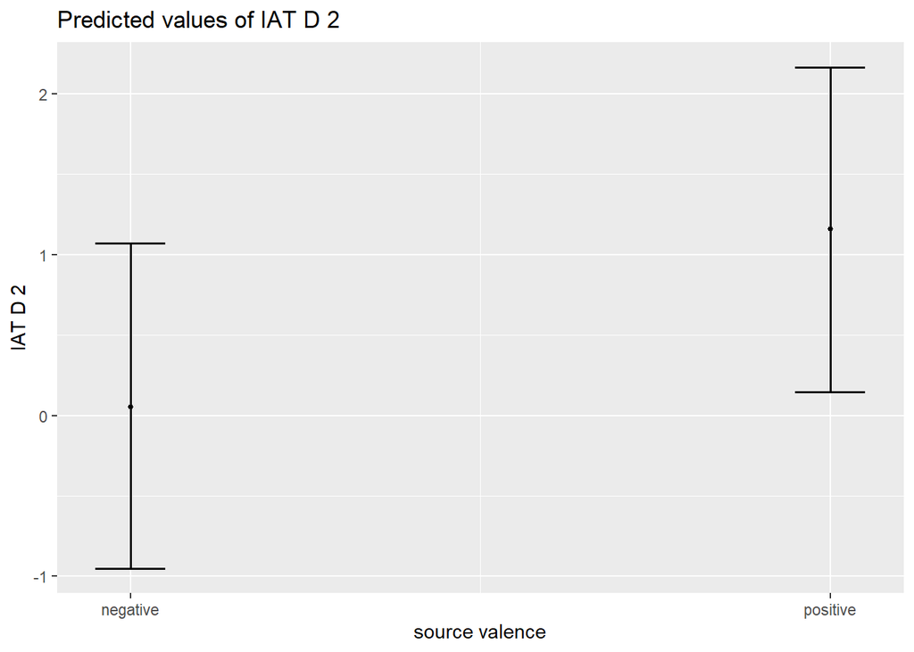

```r
fit_implicit_deepfaked_detected <-
  brm(formula = IAT_D2 ~ source_valence + (1 | experiment),
      data    = data_detectors_subset,
      file    = "models/fit_implicit_deepfaked_detected",
      prior   = prior(normal(0, 10)),
      iter    = 6000,
      warmup  = 3000,
      control = list(adapt_delta = 0.99),  # to avoid divergent transitions
      chains  = 4,
      cores   = parallel::detectCores())

# # inspect convergence
# fit_implicit_deepfaked_detected
# plot(fit_implicit_deepfaked_detected, ask = FALSE)

#plot_model(fit_implicit_deepfaked_detected)
plot_model(fit_implicit_deepfaked_detected, type = "pred", terms = "source_valence")
```

```r
draws_imp_deepfaked_detected <-
  select(spread_draws(fit_implicit_deepfaked_detected, b_source_valencepositive), b_source_valencepositive) %>%
  rename(effect_deepfaked_detected = b_source_valencepositive)

estimates_imp_deepfaked_detected <-
  map_estimate(draws_imp_deepfaked_detected) %>%
  full_join(bayestestR::hdi(draws_imp_deepfaked_detected, ci = .95) %>%
              rename(CI_95_lower = CI_low,
                     CI_95_upper = CI_high) %>%
              as_tibble(),
            by = "Parameter") %>%
  full_join(bayestestR::hdi(draws_imp_deepfaked_detected, ci = .90) %>%
              as_tibble() %>%
              rename(CI_90_lower = CI_low,
                     CI_90_upper = CI_high),
            by = "Parameter") %>%
  full_join(draws_imp_deepfaked_detected %>%
              gather(Parameter, value) %>%
              group_by(Parameter) %>%
              summarize(pd = mean(value > 0)) %>%
              mutate(p = pd_to_p(pd, direction = "one-sided")) %>%
              ungroup() %>%
              select(Parameter, p),
            by = "Parameter") %>%
  select(Parameter, MAP_Estimate, CI_95_lower, CI_95_upper,
         CI_90_lower, CI_90_upper, p)

bind_rows(filter(estimates_imp, Parameter %in% c("effect_deepfaked")),
          estimates_imp_deepfaked_detected) %>%
  mutate_at(.vars = c("MAP_Estimate", "CI_95_lower", "CI_95_upper", "CI_90_lower", "CI_90_upper"), round, digits = 2) %>%
  kable() %>%
  kable_styling(bootstrap_options = c("striped", "hover", "condensed"),
                full_width = FALSE)
```

| Parameter | MAP_Estimate | CI_95_lower | CI_95_upper | CI_90_lower | CI_90_upper | p |
| --- | --- | --- | --- | --- | --- | --- |
| effect_deepfaked | 1.45 | 1.28 | 1.60 | 1.31 | 1.57 | 0 |
| effect_deepfaked_detected | 1.10 | 0.75 | 1.47 | 0.79 | 1.40 | 0 |

## Behavioural intentions

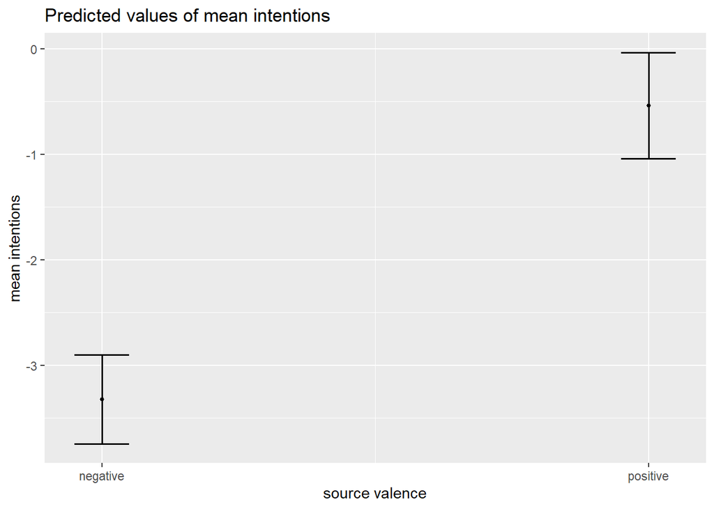

```r
fit_intentions_deepfaked_detected <-
  brm(formula = mean_intentions ~ source_valence, # no random effect for experiment as only exp 6 assessed intentions
      data    = data_detectors_subset,
      file    = "models/fit_intentions_deepfaked_detected",
      prior   = prior(normal(0, 10)),
      iter    = 6000,
      warmup  = 3000,
      control = list(adapt_delta = 0.99),  # to avoid divergent transitions
      chains  = 4,
      cores   = parallel::detectCores())

# # inspect convergence
# fit_intentions_deepfaked_detected
# plot(fit_intentions_deepfaked_detected, ask = FALSE)

#plot_model(fit_intentions_deepfaked_detected)
plot_model(fit_intentions_deepfaked_detected, type = "pred", terms = "source_valence")
```

```r
draws_intentions_deepfaked_detected <-
  select(spread_draws(fit_intentions_deepfaked_detected, b_source_valencepositive), b_source_valencepositive) %>%
  rename(effect_deepfaked_detected = b_source_valencepositive)

estimates_intentions_deepfaked_detected <-
  map_estimate(draws_intentions_deepfaked_detected) %>%
  full_join(bayestestR::hdi(draws_intentions_deepfaked_detected, ci = .95) %>%
              rename(CI_95_lower = CI_low,
                     CI_95_upper = CI_high) %>%
              as_tibble(),
            by = "Parameter") %>%
  full_join(bayestestR::hdi(draws_intentions_deepfaked_detected, ci = .90) %>%
              as_tibble() %>%
              rename(CI_90_lower = CI_low,
                     CI_90_upper = CI_high),
            by = "Parameter") %>%
  full_join(draws_intentions_deepfaked_detected %>%
              gather(Parameter, value) %>%
              group_by(Parameter) %>%
              summarize(pd = mean(value > 0)) %>%
              mutate(p = pd_to_p(pd, direction = "one-sided")) %>%
              ungroup() %>%
              select(Parameter, p),
            by = "Parameter") %>%
  select(Parameter, MAP_Estimate, CI_95_lower, CI_95_upper,
         CI_90_lower, CI_90_upper, p)

bind_rows(filter(estimates_intentions, Parameter %in% c("effect_deepfaked")),
          estimates_intentions_deepfaked_detected) %>%
  mutate_at(.vars = c("MAP_Estimate", "CI_95_lower", "CI_95_upper", "CI_90_lower", "CI_90_upper"), round, digits = 2) %>%
  kable() %>%
  kable_styling(bootstrap_options = c("striped", "hover", "condensed"),
                full_width = FALSE)
```

| Parameter | MAP_Estimate | CI_95_lower | CI_95_upper | CI_90_lower | CI_90_upper | p |
| --- | --- | --- | --- | --- | --- | --- |
| effect_deepfaked | 1.33 | 0.95 | 1.69 | 1.00 | 1.62 | 0 |
| effect_deepfaked_detected | 2.82 | 2.00 | 3.64 | 2.09 | 3.45 | 0 |